# PM566-final-project

Author

Kessie SHEN

# Central Line-Associated Bloodstream infections (CLABSI) in California Hospitals

## Description

The NHSN defines CLABSI as a laboratory-confirmed bloodstream infection that occurs in a patient who had a central venous catheter placed within 48 hours prior to the date of blood culture collection, with no other source of bacteremia or fungemia identified. This definition is based on monitoring rather than clinical presentation and does not stipulate any requirements regarding symptoms or signs of infection. Since it is often difficult to determine whether a bloodstream infection is related to the central venous catheter itself or to a secondary source of infection (such as an abdominal abscess or pneumonia), the NHSN’s definition of CLABSI may overestimate the true incidence of catheter-related infections. As a result, data interpretation can be more complex.

Studying CLABSI (Central Line-Associated Bloodstream Infections) provides significant benefits for improving patient safety and healthcare quality. By analyzing infection rates, healthcare providers can identify risk factors and implement targeted prevention strategies, reducing morbidity and mortality associated with these infections. Understanding variations in CLABSI rates across hospital types and regions allows for the development of tailored interventions and resource allocation,addressing specific challenges in different settings. Additionally, such research promotes accountability, enhances compliance with infection control protocols, and fosters continuous improvement in healthcare practices, ultimately leading to better patient outcomes and cost savings for healthcare systems.

You can download the whole final project written report by clicking [here](https://github.com/KessieSHEN/lab12website/raw/main/docs/Written-report.pdf)

Data Dictionary.after reading the Description Data Dictionary，I believe that “Facility ID” is primarily a unique identifier used to track information about hospitals or healthcare facilities in the California Department of Public Health (CDPH) Electronic Licensing Management System (ELMS).

It is important for data management and record keeping, but it has little impact on the analysis of central line-associated bloodstream infection (CLABSI) data itself and does not directly affect the analysis of infection rates or hospital performance.

Therefore, I deleted it during the merging process. Clip_Adherence_Percent was reported in only four years, and On_Track_Toward_2020_Goal appeared only in 2017 and 2018, resulting in insufficient data. For this analysis, I have temporarily removed them.

Preview of Cleaned Data

| Year | State | County | InfectNumber | Pred_Infect | CentralLINE_Days | SIR | SIR_CI_95_Lower_Limit | SIR_CI_95_Upper_Limit | Comparison | Notes | Facility_Category | Facility_Type | SIR_2015 | Months | Met_2020_Goal |
| --- | --- | --- | --- | --- | --- | --- | --- | --- | --- | --- | --- | --- | --- | --- | --- |
| 2013 | California | Santa Cruz | 4 | 10.35 | 7353 | 0.39 | 0.12 | 0.93 | Low |  | NA | NA | NA | NA | NA |
| 2013 | California | Kings-Fresno | 4 | 7.48 | 5791 | 0.54 | 0.17 | 1.29 | No difference | † See data dictionary | NA | NA | NA | NA | NA |
| 2013 | California | Fresno | 0 | 0.00 | 4 | NA | NA | NA | Too few to calculate |  | NA | NA | NA | NA | NA |
| 2013 | California | Orange | 13 | 14.39 | 8191 | 0.90 | 0.50 | 1.51 | No difference |  | NA | NA | NA | NA | NA |
| 2013 | California | Alameda | 6 | 20.33 | 11238 | 0.30 | 0.12 | 0.61 | Low | † See data dictionary | NA | NA | NA | NA | NA |
| 2013 | California | Alameda | 0 | 1.38 | 874 | 0.00 | 0.00 | 2.16 | No difference |  | NA | NA | NA | NA | NA |

## CLABSI infection rates between different regions in California.

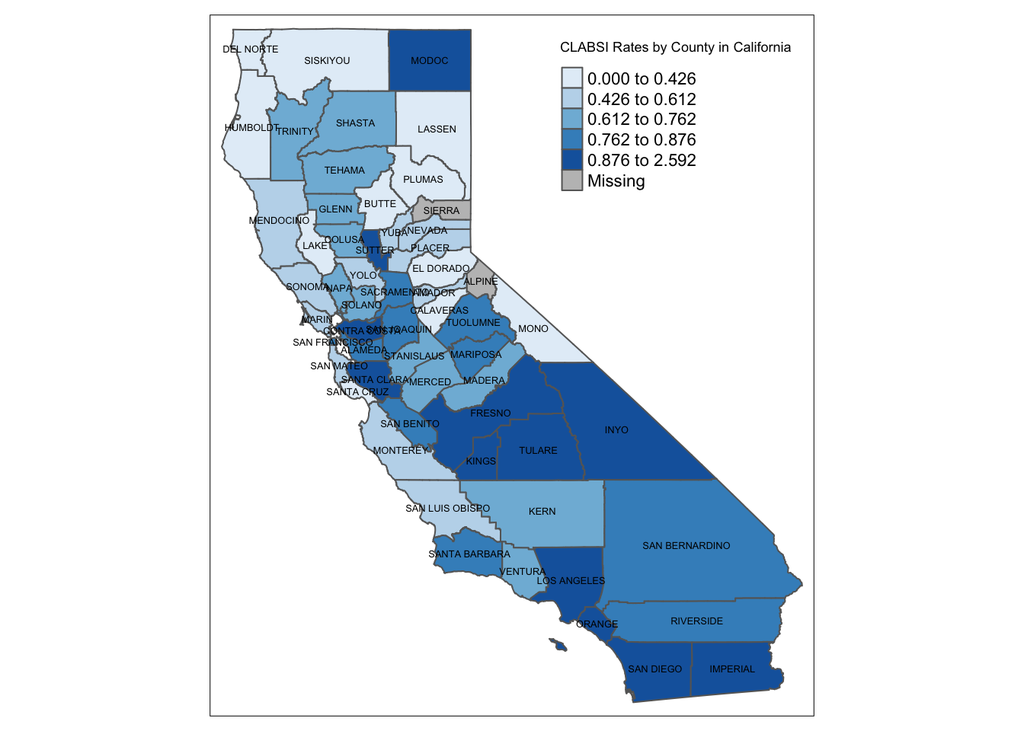

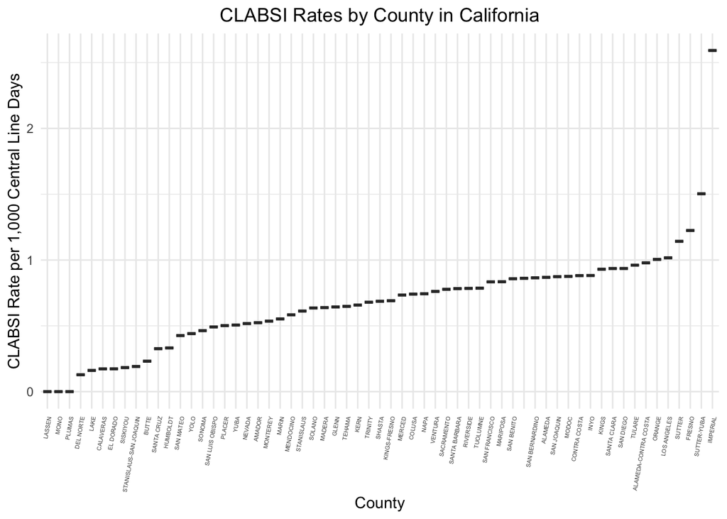

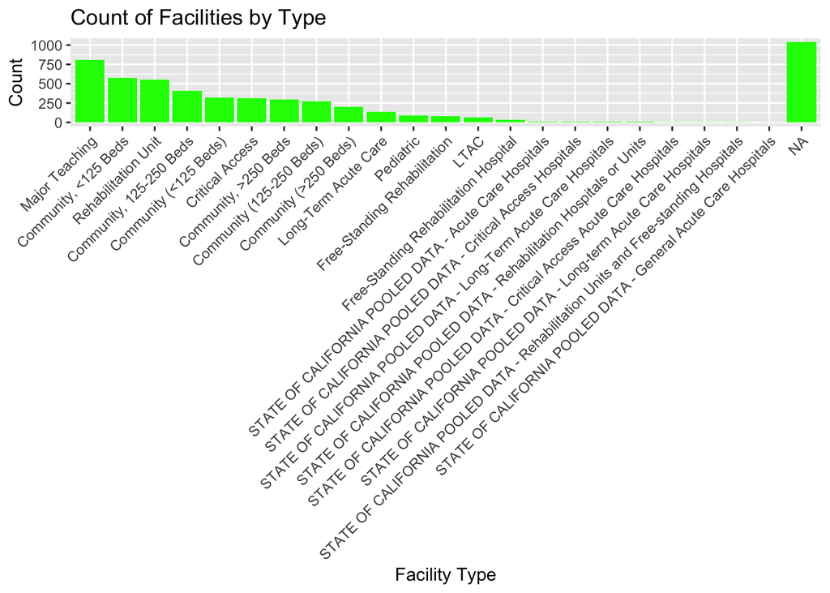

This chart shows that “Major Teaching” hospitals are the most common in California, followed by “Community” hospitals of varying bed sizes. Some specialized facilities, like LTACs and Pediatric hospitals, have much fewer facilities in comparison. It also highlights some data issues, as categories with names like “STATE OF CALIFORNIA POOLED DATA” and “NA” show up at the far right, which could be data inconsistencies or errors that need to be addressed.

# Relationships between various numerical variables

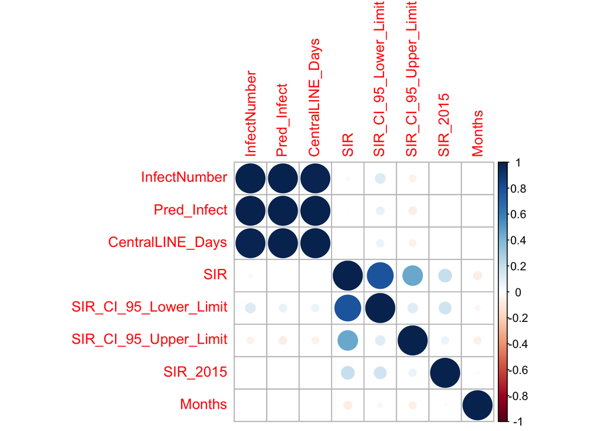

Strong Positive Correlations: There are strong positive correlations between variables such as InfectNumber, Pred_Infect, and CentralLINE_Days, indicating that as the number of infections and central line days increase, so does the predicted number of infections.

#The relationship between the incidence of CLABSI and the size of the hospital

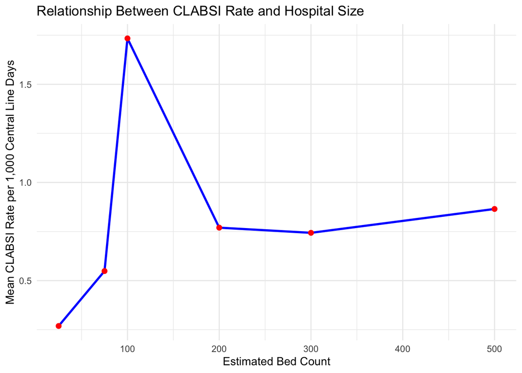

For smaller hospitals with bed counts below 100, there is a gradual increase in the CLABSI rate as bed count rises, with a sharp peak observed at around 100 beds.Hospitals with 200 estimated beds (medium size) show a substantial drop in the mean CLABSI rate compared to smaller hospitals. Beyond 300 beds (large hospitals), the mean CLABSI rate stabilizes with only minor fluctuations and a slight increase at the largest hospital size category (500 beds). This plot underscores the importance of tailoring infection prevention strategies to hospital size, as the resources and challenges vary significantly between small, medium, and large facilities.